# babette: Step by Step

Richèl J.C. Bilderbeek

2023-09-26

## Introduction

[figure not shown]

This step-by-step demo shows how to run the `babette` pipeline in detail.

First, load `babette`:

```r
library(babette)
```

In all cases, this is done for a short MCMC chain length of 10K:

```r
inference_model <- create_inference_model()
inference_model$mcmc$chain_length <- 10000
inference_model$mcmc$tracelog$filename <- normalizePath(
  get_beautier_tempfilename(
    pattern = "tracelog_", fileext = ".log"
  ),
  mustWork = FALSE
)
inference_model$mcmc$treelog$filename <- normalizePath(
  get_beautier_tempfilename(
    pattern = "treelog_",
    fileext = ".trees"
  ),
  mustWork = FALSE
)
```

## Create a ‘BEAST2’ input file

This step is commonly done using BEAUti. With `babette`, this can be done as follows:

```r
beast2_input_file <- tempfile(pattern = "beast2_", fileext = ".xml")
create_beast2_input_file_from_model(
  input_filename = get_babette_path("anthus_aco.fas"),
  inference_model = inference_model,
  output_filename = beast2_input_file
)
```

## Display (part of) the ‘BEAST2’ input file

```r
print(head(readLines(beast2_input_file)))
```

```
#> [1] "<?xml version=\"1.0\" encoding=\"UTF-8\" standalone=\"no\"?><beast beautitemplate='Standard' beautistatus='' namespace=\"beast.core:beast.evolution.alignment:beast.evolution.tree.coalescent:beast.core.util:beast.evolution.nuc:beast.evolution.operators:beast.evolution.sitemodel:beast.evolutio…
#> [2] ""
#> [3] ""
#> [4] "    <data"
#> [5] "id=\"anthus_aco\""
#> [6] "name=\"alignment\">"
```

This file can both be loaded by BEAUti and be used by ‘BEAST2’.

The file can be checked if it is indeed a valid input file:

```r
if (is_beast2_installed()) {
  is_beast2_input_file(beast2_input_file)
}
```

```
#> [1] TRUE
```

## Run MCMC

This step is commonly done using ‘BEAST2’ from the command-line or using its GUI. With `babette`, this can be done as follows:

```r
if (is_beast2_installed()) {
  beast2_options <- create_beast2_options(
    input_filename = beast2_input_file
  )
  beastier::check_can_create_file(beast2_options$output_state_filename)
  beastier::check_can_create_treelog_file(beast2_options)
  run_beast2_from_options(
    beast2_options = beast2_options
  )
  testthat::expect_true(file.exists(beast2_options$output_state_filename))
}
```

## Display (part of) the ‘BEAST2’ output files

The `.log` file contains the model parameters and parameter estimates:

```r
if (is_beast2_installed()) {
  print(head(readLines(inference_model$mcmc$tracelog$filename)))
  print(tail(readLines(inference_model$mcmc$tracelog$filename)))
}
```

```
#> [1] "#"
#> [2] "#model:"
#> [3] "#"
#> [4] "#<?xml version=\"1.0\" encoding=\"UTF-8\" standalone=\"no\"?><input id=\"posterior\" spec=\"beast.core.util.CompoundDistribution\">"
#> [5] "#    <distribution id=\"prior\" spec=\"beast.core.util.CompoundDistribution\">"
#> [6] "#        <distribution id=\"YuleModel.t:anthus_aco\" spec=\"beast.evolution.speciation.YuleModel\">"
#> [1] "5000\t-1761.3204192200221\t-1856.8658140026791\t95.54539478265697\t-1856.8658140026791\t0.01291079458323695\t95.54539478265697\t202.78110557637092"
#> [2] "6000\t-1761.5654059574215\t-1858.337673928368\t96.7722679709466\t-1858.337673928368\t0.013370667326241429\t96.7722679709466\t229.7380725652953"
#> [3] "7000\t-1758.7396712914406\t-1861.1877644644346\t102.44809317299416\t-1861.1877644644346\t0.009125245329688603\t102.44809317299416\t369.44907119208756"
#> [4] "8000\t-1766.2619613667187\t-1865.4277246825154\t99.16576331579684\t-1865.4277246825154\t0.010520208769015974\t99.16576331579684\t257.9294228628412"
#> [5] "9000\t-1760.984336956429\t-1856.231684379699\t95.24734742327003\t-1856.231684379699\t0.014481905583304693\t95.24734742327003\t253.4630847697568"
#> [6] "10000\t-1771.784990750627\t-1862.9187533221218\t91.1337625714948\t-1862.9187533221218\t0.01394547902874544\t91.1337625714948\t251.4836164360151"
```

The `.trees` file contains the alignment, taxa and posterior trees:

```r
if (is_beast2_installed()) {
  print(head(readLines(inference_model$mcmc$treelog$filename)))
  print(tail(readLines(inference_model$mcmc$treelog$filename)))
}
```

[output not shown]

The `.xml.state` file contains the final state of the MCMC run and the MCMC operator acceptances thus far:

```r
if (is_beast2_installed()) {
  print(head(readLines(beast2_options$output_state_filename)))
  print(tail(readLines(beast2_options$output_state_filename)))
}
```

```
#> [1] "<itsabeastystatewerein version='2.0' sample='10000'>"
#> [2] "<statenode id='Tree.t:anthus_aco'>(((((((0:5.640509028850157E-4,4:5.640509028850157E-4)24:2.6680946098870555E-4,2:8.308603638737213E-4)36:7.295543716622958E-4,16:0.001560414735536017)34:0.0015705220234042607,10:0.0031309367589402778)31:0.004055419525075088,((((3:0.001052267323852714,14:0.001…
#> [3] "<statenode id='birthRate.t:anthus_aco'>birthRate.t:anthus_aco[1 1] (-Infinity,Infinity): 251.4836164360151 </statenode>"
#> [4] "</itsabeastystatewerein>"
#> [5] "<!--"
#> [6] "{\"operators\":["
#> [1] "{\"id\":\"YuleModelSubtreeSlide.t:anthus_aco\",\"p\":1,\"accept\":5,\"reject\":2011,\"acceptFC\":0,\"rejectFC\":0,\"rejectIv\":949,\"rejectOp\":949},"
#> [2] "{\"id\":\"YuleModelNarrow.t:anthus_aco\",\"p\":\"NaN\",\"accept\":905,\"reject\":1080,\"acceptFC\":0,\"rejectFC\":0,\"rejectIv\":0,\"rejectOp\":0},"
#> [3] "{\"id\":\"YuleModelWide.t:anthus_aco\",\"p\":\"NaN\",\"accept\":14,\"reject\":366,\"acceptFC\":0,\"rejectFC\":0,\"rejectIv\":206,\"rejectOp\":206},"
#> [4] "{\"id\":\"YuleModelWilsonBalding.t:anthus_aco\",\"p\":\"NaN\",\"accept\":50,\"reject\":386,\"acceptFC\":0,\"rejectFC\":0,\"rejectIv\":67,\"rejectOp\":67}"
#> [5] "]}"
#> [6] "-->"
```

## Parse output

This step is commonly done using Tracer. With `babette`, this can be done as follows.

Parsing `.log` file to obtain the parameter estimates:

```r
if (is_beast2_installed()) {
  knitr::kable(
    head(parse_beast_tracelog_file(inference_model$mcmc$tracelog$filename))
  )
}
```

| Sample | posterior | likelihood | prior | treeLikelihood | TreeHeight | YuleModel | birthRate |
| --- | --- | --- | --- | --- | --- | --- | --- |
| 0 | -6879.867 | -6869.726 | -10.14191 | -6869.726 | 3.3665920 | -10.14191 | 1.00000 |
| 1000 | -1918.589 | -1991.985 | 73.39653 | -1991.985 | 0.0268112 | 73.39653 | 47.27918 |
| 2000 | -1767.270 | -1857.064 | 89.79335 | -1857.064 | 0.0122694 | 89.79335 | 140.42977 |
| 3000 | -1763.245 | -1861.037 | 97.79241 | -1861.037 | 0.0106426 | 97.79241 | 234.51126 |
| 4000 | -1758.597 | -1858.961 | 100.36453 | -1858.961 | 0.0131173 | 100.36453 | 297.03691 |
| 5000 | -1761.320 | -1856.866 | 95.54539 | -1856.866 | 0.0129108 | 95.54539 | 202.78111 |

Parsing `.trees` file to obtain the posterior phylogenies:

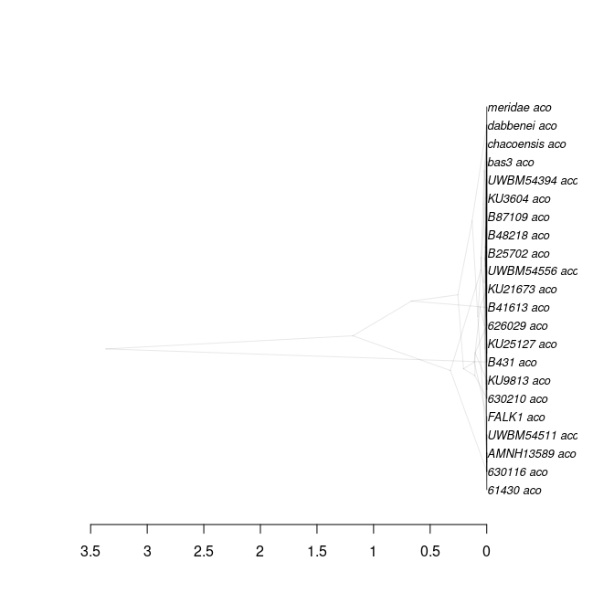

```r
if (is_beast2_installed()) {
  plot_densitree(parse_beast_trees(inference_model$mcmc$treelog$filename))
}
```

Parsing `.xml.state` file to obtain the MCMC operator acceptances:

```r
if (is_beast2_installed()) {
  knitr::kable(
    head(parse_beast_state_operators(beast2_options$output_state_filename))
  )
}
```

| operator | p | accept | reject | acceptFC | rejectFC | rejectIv | rejectOp |
| --- | --- | --- | --- | --- | --- | --- | --- |
| YuleBirthRateScaler.t | 0.75 | 275 | 110 | 0 | 0 | 0 | 0 |
| YuleModelTreeScaler.t | 0.50 | 83 | 275 | 0 | 0 | 0 | 0 |
| YuleModelTreeRootScaler.t | 0.50 | 92 | 314 | 0 | 0 | 48 | 48 |
| YuleModelUniformOperator.t | NaN | 2360 | 1675 | 0 | 0 | 0 | 0 |
| YuleModelSubtreeSlide.t | 1.00 | 5 | 2011 | 0 | 0 | 949 | 949 |
| YuleModelNarrow.t | NaN | 905 | 1080 | 0 | 0 | 0 | 0 |